# Assignment7

By *Changyu Gao*, PB15121717

## 8.12

Import data

```r
X1 <- read.table('T1-5.DAT')
head(X1)
```

```
##   V1  V2 V3 V4 V5 V6 V7
## 1  8  98  7  2 12  8  2
## 2  7 107  4  3  9  5  3
## 3  7 103  4  3  5  6  3
## 4 10  88  5  2  8 15  4
## 5  6  91  4  2  8 10  3
## 6  8  90  5  2 12 12  4
```

```r
S1 <- cov(X1)
R1 <- cov2cor(S1)
pca1 <- prcomp(X1)
summary(pca1)
```

```
## Importance of components:
##                           PC1     PC2     PC3     PC4     PC5     PC6
## Standard deviation     17.443 5.31753 3.38592 1.58881 1.13116 0.72714
## Proportion of Variance  0.873 0.08113 0.03289 0.00724 0.00367 0.00152
## Cumulative Proportion   0.873 0.95408 0.98697 0.99421 0.99788 0.99940
##                           PC7
## Standard deviation     0.4578
## Proportion of Variance 0.0006
## Cumulative Proportion  1.0000
```

```r
cat("First principal component using covariance matrix:")
```

```
## First principal component using covariance matrix:
```

```r
pca1$rotation[,1]
```

```
##           V1           V2           V3           V4           V5
## -0.010039244  0.993199405  0.014062314 -0.004710175  0.024255644
##           V6           V7
##  0.112429558  0.002340785
```

```r
pcar1 <- prcomp(X1, scale. = T)
summary(pcar1)
```

```
## Importance of components:
##                           PC1    PC2    PC3    PC4     PC5     PC6     PC7
## Standard deviation     1.5287 1.1773 1.0973 0.8527 0.80838 0.73259 0.39484
## Proportion of Variance 0.3338 0.1980 0.1720 0.1039 0.09335 0.07667 0.02227
## Cumulative Proportion  0.3338 0.5318 0.7038 0.8077 0.90106 0.97773 1.00000
```

```r
cat("First three principal components using covariance matrix:")
```

[output not shown]

```r
pcar1$rotation[,1:3]
```

```
##           PC1          PC2        PC3
## V1 -0.2368211  0.278445138 -0.6434744
## V2  0.2055665 -0.526613869 -0.2244690
## V3  0.5510839 -0.006819502  0.1136089
## V4  0.3776151  0.434674253  0.4070978
## V5  0.4980161  0.199767367 -0.1965567
## V6  0.3245506 -0.566973655 -0.1598465
## V7  0.3194032  0.307882771 -0.5410484
```

We can see great difference between the result obtained using S vs. R. Since measurements differ in scale, there variances differ sharply. Variance of solar radiation is much greater than those of others. Therefore, in the first principal component (87% of total variance) obtained using covariance matrix, the coefficient of solar radiation is 0.993. This makes the solar radiation the major indicator, which is inappropriate. Using the standardized correlation matrix solves this problem, making variables on a similar scale. We observe from the first component that the coef of wind is negative while coefs of others are positive. This may imply some overall air pollution level. First three PCs account for 70.4% of total sample variance while first four contribute to 80.8% of total. Hence, we can summarize the data in three dimensions.

## 8.14

Import data

```r
X2 <- read.table("T5-1.DAT")
head(X2)
```

```
##    V1   V2   V3
## 1 3.7 48.5  9.3
## 2 5.7 65.1  8.0
## 3 3.8 47.2 10.9
## 4 3.2 53.2 12.0
## 5 3.1 55.5  9.7
## 6 4.6 36.1  7.9
```

```r
pca2 <- prcomp(X2)
summary(pca2)
```

```
## Importance of components:
##                            PC1     PC2     PC3
## Standard deviation     14.1585 2.12875 1.14079
## Proportion of Variance  0.9717 0.02197 0.00631
## Cumulative Proportion   0.9717 0.99369 1.00000
```

```r
v1 <- pca2$rotation[,1]
cat("First principal component:")
```

```
## First principal component:
```

```r
print(v1)
```

```
##          V1          V2          V3
##  0.05084144  0.99828352 -0.02907156
```

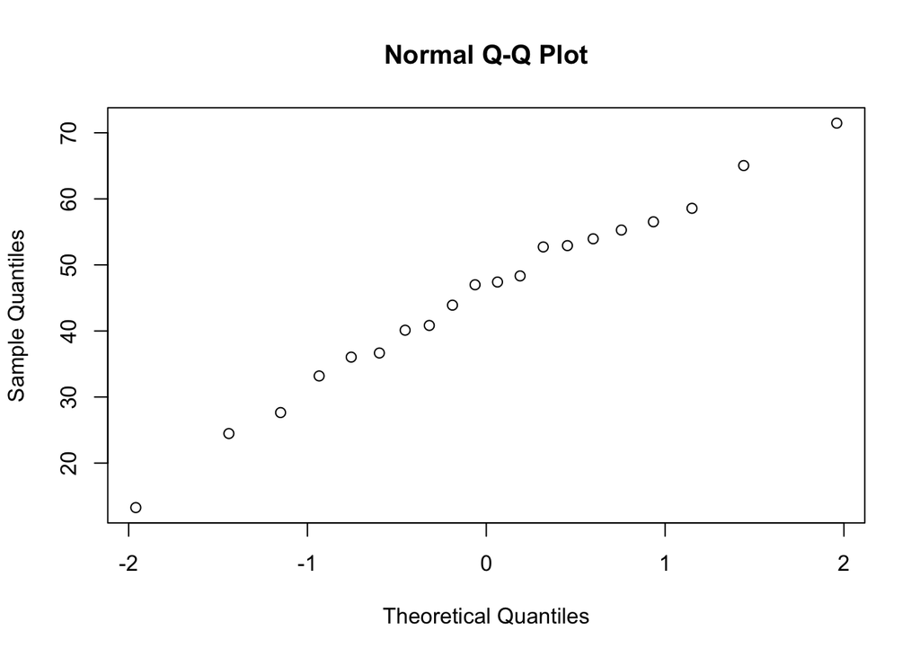

```r
X2_pc1 <- as.matrix(X2) %*% as.vector(v1) # compute first pc
qqnorm(X2_pc1)
```

We find out that the first principal component accounts for 97% of total sample variance and that coefficient of sodium is 0.998. This results from the large sample variance of sodium (scale much larger compared to other variables). We construct the Q-Q plot of the first principal component. There are no suspect observations as we observe that the points nearly lie on a straight line.

## 8.17

Import data

```r
X3 <- read.table("T1-8.DAT")
head(X3)
```

```
##      V1    V2    V3    V4    V5    V6
## 1 1.103 1.052 2.139 2.238 0.873 0.872
## 2 0.842 0.859 1.873 1.741 0.590 0.744
## 3 0.925 0.873 1.887 1.809 0.767 0.713
## 4 0.857 0.744 1.739 1.547 0.706 0.674
## 5 0.795 0.809 1.734 1.715 0.549 0.654
## 6 0.787 0.779 1.509 1.474 0.782 0.571
```

```r
pca3 <- prcomp(X3)
summary(pca3)
```

```
## Importance of components:
##                           PC1     PC2     PC3     PC4     PC5     PC6
## Standard deviation     0.4044 0.13547 0.08982 0.05793 0.04715 0.02976
## Proportion of Variance 0.8326 0.09343 0.04107 0.01709 0.01132 0.00451
## Cumulative Proportion  0.8326 0.92601 0.96709 0.98417 0.99549 1.00000
```

```r
eigval <- pca3$sdev ^ 2 # eigenvalues
eigval
```

```
## [1] 0.1635444886 0.0183513894 0.0080676521 0.0033560879 0.0022235060
## [6] 0.0008856094
```

```r
pca3$rotation[, 1:2] # show eigenvectors, i.e. principal components
```

```
##           PC1         PC2
## V1 -0.2177361 -0.33749131
## V2 -0.2040332 -0.43168983
## V3 -0.6729095  0.49978457
## V4 -0.6325160 -0.02390969
## V5 -0.1813135 -0.43027881
## V6 -0.1587551 -0.51404996
```

We see that the first principal component accounts for 83% of total sample variance and first two account for 92.6% of total. First two principal components are shown above.